# Poisson Regression Model

J. Heffaran

2026-11-02

This note book shall detail my poisson regression model

## Section 1: Gathering data

We will gather both premier league and championship data for this model. The championship data is to be used to estimate team attack and defence ratings for newly promoted teams.

We will form two datasets, one for prem game results and one for championship.

We now have two df which contain all the epl (premier league) and ech (championship) game data. We can view the data below.

```r
head(ech_all)
```

```
##     Season       Date     HomeTeam       AwayTeam FTHG FTAG
## 1 ech_1415 2014-08-08    Blackburn        Cardiff    1    1
## 2 ech_1415 2014-08-09    Brentford       Charlton    1    1
## 3 ech_1415 2014-08-09     Brighton Sheffield Weds    0    1
## 4 ech_1415 2014-08-09        Derby      Rotherham    1    0
## 5 ech_1415 2014-08-09 Huddersfield    Bournemouth    0    4
## 6 ech_1415 2014-08-09      Ipswich         Fulham    2    1
```

```r
head(epl_all)
```

```
##     Season       Date   HomeTeam       AwayTeam FTHG FTAG
## 1 epl_1415 2014-08-16    Arsenal Crystal Palace    2    1
## 2 epl_1415 2014-08-16  Leicester        Everton    2    2
## 3 epl_1415 2014-08-16 Man United        Swansea    1    2
## 4 epl_1415 2014-08-16        QPR           Hull    0    1
## 5 epl_1415 2014-08-16      Stoke    Aston Villa    0    1
## 6 epl_1415 2014-08-16  West Brom     Sunderland    2    2
```

We want to construct a filtration so as to remove any information we do not yet have access to so that we can prevent information leakage. We construct our new training data frames below. The following is illustrative since we define functions to do same later on.

```r
known_date <- as.Date("2025-01-19") # date upto which we have full information
cut_off <- 730 # a param used in time weighting, obvs this many days from known
               # date will have a weight of zero

train_ech <- ech_all %>%
  filter(Date < known_date) %>%
  mutate(days_ago = as.numeric(known_date - Date)) %>%
  filter(days_ago < cut_off)

train_epl <- epl_all %>%
  filter(Date < known_date) %>%
  mutate(days_ago = as.numeric(known_date - Date)) %>%
  filter(days_ago < cut_off)
```

The training data sets can now be used to form team attack and defence ratings for prediction. First we start of with our weighting function:

$$w(x) = \begin{cases}
1 - \left(\dfrac{x}{c}\right)^p, & 0 \le d < c,\\[6pt]
0, & d \ge c,
\end{cases}$$
where x is the days from obvs to known date, c is a cut-off, and p is a shape parameter.

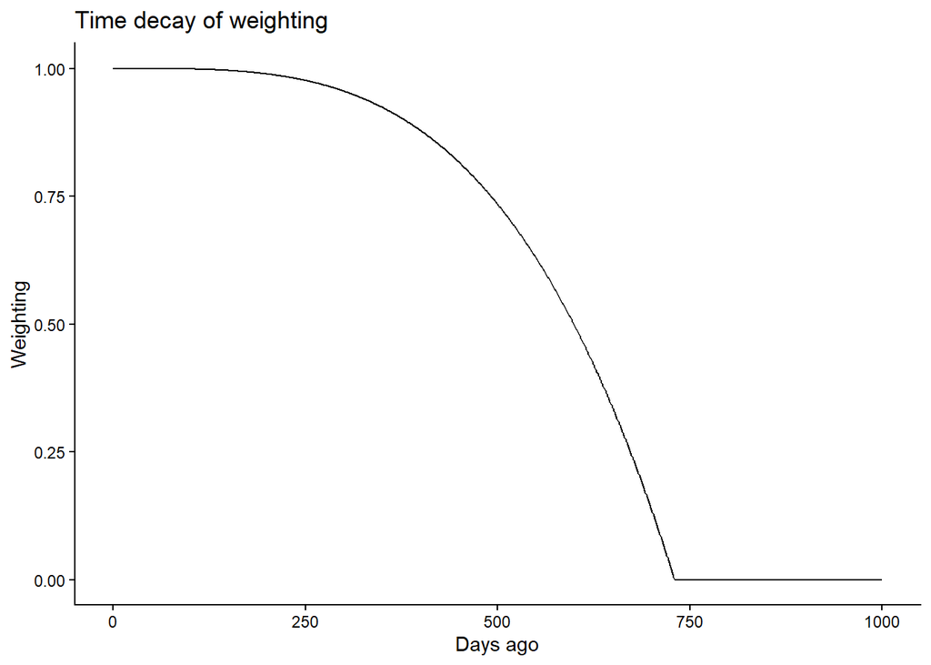

In our weighting function we have a cut-off parameter which controls when we stop taking account of data, and a power parameter which controls the shape of the decay. A larger power parameter causes a greater period of high weighting, followed by a steeper decay to zero.

Now since we will create multiple training snapshots, we will define a function to automate the creation of the training snapshot. We will also create a validation df which consists of games after the known date up to the end of some validation window.

```r
def_training_data <- function(data, known_date_, cut_off_, power_,
                              validation_length_) {

  train_data <- data %>%
    filter(!is.na(Date), Date < known_date_) %>%
    mutate(days_ago = as.numeric(known_date_ - Date)) %>%
    filter(days_ago < cut_off_) %>%
    mutate(obvs_weight = weight(days_ago, power= power_, cut_off = cut_off_))

  validation_data <- data %>%
    filter(!is.na(Date), Date >= known_date_) %>%
    mutate(days_to = as.numeric(Date - known_date_ )) %>%
    filter(days_to <= validation_length_)

  return(list(train = train_data, validation = validation_data))}
```

Let us use this function to create our first two training snapshots, we will also extract our validation data at same time.

```r
known_date <- as.Date("2025-01-19")
cut_off <- 730
weight_power <- 3

train_ech <- def_training_data(ech_all, known_date_ = known_date,
                               cut_off_ = cut_off, power_ = weight_power,
                               validation_length_ = 133)$train

validation_ech <- def_training_data(ech_all, known_date_ = known_date,
                               cut_off_ = cut_off, power_ = weight_power,
                               validation_length_ = 133)$validation

train_epl <- def_training_data(epl_all, known_date_ = known_date,
                               cut_off_ = cut_off, power_ = weight_power,
                               validation_length_ = 133)$train

validation_epl <- def_training_data(epl_all, known_date_ = known_date,
                               cut_off_ = cut_off, power_ = weight_power,
                               validation_length_ = 133)$validation
```

Due to the way the dixon_coles adjuster works later on, we will label certain data as for use by that model.

```r
train_dc_epl <- train_epl
train_dc_ech <- train_ech
validation_dc_epl <- validation_epl
validation_dc_ech <- validation_ech
```

Now we have our basic training data, we will adjust it so as to give each team an unique row per game. This will allow us to use poisson regression on the home and away teams realised scores. We create the function to create the goal data below. We will create a seperate function for the splitting of train and validataion data since validation data has no attached weights.

```r
def_home_away_split_train <- function(data) {
home_data <- data %>%
  transmute(Date, Team = HomeTeam, Opponent = AwayTeam, Goals = FTHG, Home = 1,
            obvs_weight = obvs_weight)

away_data <- data %>%
  transmute(Date, Team = AwayTeam, Opponent = HomeTeam, Goals = FTAG, Home = 0,
            obvs_weight = obvs_weight)

train_goal_data <- bind_rows(home_data, away_data)

return(train_goal_data)}

def_home_away_split_validation <- function(data) {
home_data <- data %>%
  transmute(Date, Team = HomeTeam, Opponent = AwayTeam, Goals = FTHG, Home = 1)

away_data <- data %>%
  transmute(Date, Team = AwayTeam, Opponent = HomeTeam, Goals = FTAG, Home = 0)

validation_goal_data <- bind_rows(home_data, away_data)

return(validation_goal_data)}
```

We’re now going to use our function to create our home away split goal data.

```r
train_ech_goals <- def_home_away_split_train(train_ech)
train_epl_goals <- def_home_away_split_train(train_epl)
```

## Section 2: Poisson regression model for team ratings

We are now going to fit a poisson regression model to obtain attack and defence ratings for the teams observed in our train data. Note that it we will model the scoreline for individual games under the dixon coles model. This models the home and away goals as poisson random variables, with a correction term which adjusts the probability of observing low-scoring scorelines.

```r
ech_goal_model <- glm(
  Goals ~ Home + Team + Opponent,
  family = poisson(link = "log"),
  data = train_ech_goals,
  weights = obvs_weight)

epl_goal_model <- glm(
  Goals ~ Home + Team + Opponent,
  family = poisson(link = "log"),
  data = train_epl_goals,
  weights = obvs_weight)

summary(epl_goal_model)
```

```
##
## Call:
## glm(formula = Goals ~ Home + Team + Opponent, family = poisson(link = "log"),
##     data = train_epl_goals, weights = obvs_weight)
##
## Coefficients:
##                          Estimate Std. Error z value Pr(>|z|)
## (Intercept)               0.14098    0.16803   0.839 0.401452
## Home                      0.13887    0.04680   2.967 0.003005 **
## TeamAston Villa          -0.21462    0.13204  -1.625 0.104074
## TeamBournemouth          -0.38915    0.13850  -2.810 0.004958 **
## TeamBrentford            -0.31054    0.13547  -2.292 0.021888 *
## TeamBrighton             -0.38408    0.13905  -2.762 0.005741 **
## TeamBurnley              -0.68668    0.19052  -3.604 0.000313 ***
## TeamChelsea              -0.11160    0.12887  -0.866 0.386503
## TeamCrystal Palace       -0.46965    0.14137  -3.322 0.000893 ***
## TeamEverton              -0.83502    0.16179  -5.161 2.46e-07 ***
## TeamFulham               -0.39391    0.13812  -2.852 0.004347 **
## TeamIpswich              -0.80788    0.24064  -3.357 0.000787 ***
## TeamLeeds                -0.54436    0.41724  -1.305 0.192008
## TeamLeicester            -0.69289    0.20697  -3.348 0.000814 ***
## TeamLiverpool             0.03694    0.12306   0.300 0.764073
## TeamLuton                -0.43541    0.17366  -2.507 0.012168 *
## TeamMan City              0.01068    0.12394   0.086 0.931358
## TeamMan United           -0.44345    0.14089  -3.147 0.001647 **
## TeamNewcastle            -0.08078    0.12640  -0.639 0.522779
## TeamNott'm Forest        -0.47846    0.14309  -3.344 0.000826 ***
## TeamSheffield United     -0.82598    0.20339  -4.061 4.88e-05 ***
## TeamSouthampton          -1.04589    0.24619  -4.248 2.15e-05 ***
## TeamTottenham            -0.10014    0.12873  -0.778 0.436615
## TeamWest Ham             -0.40718    0.14000  -2.908 0.003633 **
## TeamWolves               -0.47616    0.14386  -3.310 0.000934 ***
## OpponentAston Villa       0.54410    0.17490   3.111 0.001866 **
## OpponentBournemouth       0.53456    0.17483   3.058 0.002232 **
## OpponentBrentford         0.62591    0.17175   3.644 0.000268 ***
## OpponentBrighton          0.53272    0.17497   3.045 0.002330 **
## OpponentBurnley           0.80007    0.18667   4.286 1.82e-05 ***
## OpponentChelsea           0.54491    0.17547   3.105 0.001900 **
## OpponentCrystal Palace    0.45878    0.17745   2.585 0.009726 **
## OpponentEverton           0.39511    0.18029   2.192 0.028412 *
```

[output cut: 10 more lines]

```
## OpponentSheffield United  1.10094    0.17533   6.279 3.40e-10 ***
## OpponentSouthampton       0.90908    0.19133   4.751 2.02e-06 ***
## OpponentTottenham         0.60728    0.17347   3.501 0.000464 ***
## OpponentWest Ham          0.77820    0.16762   4.643 3.44e-06 ***
## OpponentWolves            0.76087    0.16847   4.516 6.29e-06 ***
## ---
## Signif. codes:  0 '***' 0.001 '**' 0.01 '*' 0.05 '.' 0.1 ' ' 1
##
## (Dispersion parameter for poisson family taken to be 1)
##
##     Null deviance: 1412.4  on 1569  degrees of freedom
## Residual deviance: 1172.6  on 1522  degrees of freedom
## AIC: 3550.9
##
## Number of Fisher Scoring iterations: 5
```

```r
summary(ech_goal_model)
```

```
##
## Call:
## glm(formula = Goals ~ Home + Team + Opponent, family = poisson(link = "log"),
##     data = train_ech_goals, weights = obvs_weight)
##
## Coefficients:
##                           Estimate Std. Error z value Pr(>|z|)
## (Intercept)              -0.060655   0.202980  -0.299 0.765074
## Home                      0.281612   0.043862   6.420 1.36e-10 ***
## TeamBlackburn             0.184254   0.186623   0.987 0.323495
## TeamBlackpool             0.104394   0.497015   0.210 0.833635
## TeamBristol City          0.118590   0.187905   0.631 0.527964
## TeamBurnley               0.160826   0.222916   0.721 0.470622
## TeamCardiff               0.080067   0.189674   0.422 0.672930
## TeamCoventry              0.330298   0.181706   1.818 0.069100 .
## TeamDerby                 0.132834   0.235880   0.563 0.573338
## TeamHuddersfield          0.045213   0.212150   0.213 0.831236
## TeamHull                  0.197619   0.186079   1.062 0.288228
## TeamIpswich               0.642542   0.190026   3.381 0.000721 ***
## TeamLeeds                 0.540517   0.177992   3.037 0.002391 **
## TeamLeicester             0.604000   0.191213   3.159 0.001584 **
## TeamLuton                 0.005799   0.233619   0.025 0.980196
## TeamMiddlesbrough         0.453947   0.178683   2.541 0.011069 *
## TeamMillwall             -0.070718   0.195132  -0.362 0.717043
## TeamNorwich               0.456685   0.178830   2.554 0.010657 *
## TeamOxford                0.083982   0.238134   0.353 0.724340
## TeamPlymouth              0.084985   0.192037   0.443 0.658093
## TeamPortsmouth            0.222415   0.233828   0.951 0.341507
## TeamPreston               0.091857   0.189124   0.486 0.627184
## TeamQPR                   0.007917   0.191734   0.041 0.967065
## TeamReading              -0.281882   0.597763  -0.472 0.637240
## TeamRotherham            -0.245376   0.229157  -1.071 0.284270
## TeamSheffield United      0.337042   0.214240   1.573 0.115672
## TeamSheffield Weds        0.142011   0.190269   0.746 0.455444
## TeamSouthampton           0.600844   0.191746   3.134 0.001727 **
## TeamStoke                -0.003524   0.192981  -0.018 0.985432
## TeamSunderland            0.208155   0.185931   1.120 0.262914
## TeamSwansea               0.177066   0.186254   0.951 0.341772
## TeamWatford               0.275247   0.183806   1.497 0.134266
## TeamWest Brom             0.296928   0.182664   1.626 0.104048
```

[output cut: 28 more lines]

```
## OpponentSunderland       -0.268607   0.176627  -1.521 0.128321
## OpponentSwansea          -0.036747   0.168036  -0.219 0.826895
## OpponentWatford          -0.011468   0.167405  -0.069 0.945385
## OpponentWest Brom        -0.344787   0.179661  -1.919 0.054972 .
## OpponentWigan            -0.301385   0.546364  -0.552 0.581209
## ---
## Signif. codes:  0 '***' 0.001 '**' 0.01 '*' 0.05 '.' 0.1 ' ' 1
##
## (Dispersion parameter for poisson family taken to be 1)
##
##     Null deviance: 1989.2  on 2203  degrees of freedom
## Residual deviance: 1751.8  on 2138  degrees of freedom
## AIC: 4728.9
##
## Number of Fisher Scoring iterations: 5
```

We will now extract the attack and defence ratings as suggested by our regression model. The model uses reference levels for the team and opponent factors to ensure identifiability. We then centre the estimated log attack and defence effects and adjust the baseline accordingly. This produces ratings with geometric mean one while preserving the fitted expected goals.

```r
extract_ratings <- function(model) {

  teams <- model$xlevels$Team
  coefs <- coef(model)

  # initialise each teams log_attack rating
  attack_log <- setNames(rep(0, length(teams)), teams)
  defence_log <- setNames(rep(0, length(teams)), teams)

  # now we extract ratings
  for (team in teams) {

    attack_name <- paste0("Team", team)
    defence_name <- paste0("Opponent", team)

    if (attack_name %in% names(coefs)) {     # since baseline team has no coefs,
      attack_log[team] <- coefs[attack_name]} # we only update teams with coefs

    if (defence_name %in% names(coefs)) {
      defence_log[team] <- coefs[defence_name]}}

  # center the log ratings so that prem and champ ratings can be scaled later
  mean_attack <- mean(attack_log)
  mean_defence <- mean(defence_log)

  ratings <- data.frame(team_names = teams,
    att_rating = exp(attack_log - mean_attack),
    def_rating = exp(defence_log - mean_defence))

  baseline <- unname(coefs["(Intercept)"]) + mean_attack + mean_defence
  home_advantage <- unname(coefs["Home"])

  return(list(ratings = ratings, baseline = baseline,
              home_advantage = home_advantage))}
```

We implement the function below:

```r
epl_model <- extract_ratings(epl_goal_model)
ech_model <- extract_ratings(ech_goal_model)

epl_ratings <- epl_model$ratings
ech_ratings <- ech_model$ratings

epl_baseline <- epl_model$baseline
epl_home_advantage <- epl_model$home_advantage

ech_baseline <- ech_model$baseline
ech_home_advantage <- ech_model$home_advantage

head(epl_ratings)
```

```
##              team_names att_rating def_rating
## Arsenal         Arsenal  1.5223572  0.5466645
## Aston Villa Aston Villa  1.2283084  0.9419367
## Bournemouth Bournemouth  1.0315968  0.9329869
## Brentford     Brentford  1.1159646  1.0222314
## Brighton       Brighton  1.0368394  0.9312713
## Burnley         Burnley  0.7661162  1.2167090
```

Above we show the head of epl_ratings obtained by our poisson regression. These ratings have geometric mean 1. That is an attack rating greater than 1 is given to a team who has a stronger attack, a defence rating below 1 is given to a team who has a stronger defence.

We will now see how these perform compared to our validation data. We will first transform our raw validation data via the home away goal split.

```r
validation_ech <- def_home_away_split_validation(validation_ech)
validation_epl <- def_home_away_split_validation(validation_epl)
```

We use the predict function to give the number of goals we expect to see in our validation data.

```r
validation_epl$predicted_goals <- predict(
  epl_goal_model, newdata = validation_epl, type = "response")

validation_ech$predicted_goals <- predict(
  ech_goal_model, newdata = validation_ech, type = "response")
```

Now lets evaluate our model on the validation data. This is all for sanity check to make sure our model is suggesting reasonable estimated goals.

```r
evaluate_goals <- function(data) {
  errors <- data$Goals - data$predicted_goals

  data.frame(
    n = nrow(data),
    mean_actual = mean(data$Goals), mean_predicted = mean(data$predicted_goals),
    MAE = mean(abs(errors)), RMSE = sqrt(mean(errors^2)))}
```

```r
baseline_evaluate <- function(train_data, validation_data) {
  mean_train_goals <- mean(train_data$Goals)
  errors <- validation_data$Goals - mean_train_goals

  data.frame(
    baseline_mean = mean_train_goals, MAE = mean(abs(errors)),
    RMSE = sqrt(mean(errors^2)))}
```

```r
weighted_baseline_evaluate <- function(train_data, validation_data) {

  weighted_mean_train_goals <- weighted.mean(train_data$Goals,
                                             w= train_data$obvs_weight)

  errors <- validation_data$Goals - weighted_mean_train_goals

  data.frame(
    baseline_mean = weighted_mean_train_goals, MAE = mean(abs(errors)),
    RMSE = sqrt(mean(errors^2)))}
```

```r
evaluation_results <- bind_rows(
  # Championship
  tibble(league = "Championship",
    method = "Weighted baseline",
    weighted_baseline_evaluate(train_ech_goals, validation_ech)),
  tibble(league = "Championship",method = "Unweighted baseline",baseline_evaluate(train_ech_goals, validation_ech)),
  tibble(league = "Championship",
    method = "Poisson model", evaluate_goals(validation_ech)),

  # Premier League
  tibble(league = "Premier League", method = "Weighted baseline",
    weighted_baseline_evaluate(train_epl_goals, validation_epl)), tibble(
    league = "Premier League",
    method = "Unweighted baseline",baseline_evaluate(train_epl_goals,
                                                     validation_epl)),
  tibble(league = "Premier League", method = "Poisson model",
    evaluate_goals(validation_epl))) %>%
  select(league, method,MAE,RMSE)

evaluation_results
```

```
## # A tibble: 6 × 4
##   league         method                MAE  RMSE
##   <chr>          <chr>               <dbl> <dbl>
## 1 Championship   Weighted baseline   0.865  1.12
## 2 Championship   Unweighted baseline 0.862  1.12
## 3 Championship   Poisson model       0.805  1.07
## 4 Premier League Weighted baseline   1.02   1.26
## 5 Premier League Unweighted baseline 1.02   1.25
## 6 Premier League Poisson model       0.951  1.21
```

Okay so our poisson goals model seems to perform slightly better than our baseline estimate of just expecting to see the average number of goals from our training data. We will now look to use a Dixon-Coles correction in order to improve the accuracy with which we predict the number of goals in a game.

We have a more indepth breakdown of the evaluation for our Poisson model below:

```
##           league  method   n mean_actual mean_predicted       MAE     RMSE
## 1   Championship Poisson 460    1.228261       1.237960 0.8051330 1.066468
## 2 Premier League Poisson 332    1.436747       1.533651 0.9512713 1.205572
```

## Section 3: Dixon-Coles adjustment

We are going to use the attack and defence ratings from the fitted poisson model in our dixon coles adjusted model for game out come (at least we will initially) . Note that we should really fit these by maximising the likelihood of our observations under the dixon coles model. However, that would require us to maximise the custom likelihood function. We will aim to do this if testing for this model proves positive.

```r
dixon_coles_probs <- function(team_ratings, home_team, away_team, baseline, home_advantage,
                              rho = -0.05, max_goals = 10) {

  # get team ratings
  home_att <- team_ratings$att_rating[team_ratings$team_names == home_team]

  home_def <- team_ratings$def_rating[team_ratings$team_names == home_team]

  away_att <- team_ratings$att_rating[team_ratings$team_names == away_team]

  away_def <- team_ratings$def_rating[team_ratings$team_names == away_team]

  # Expected goals
  lambda <- exp(baseline + home_advantage) * home_att * away_def
  mu <- exp(baseline) * away_att * home_def

  goals <- 0:max_goals

  # Independent Poisson scoreline probabilities
  probs <- outer(dpois(goals, lambda), dpois(goals, mu))

  # correction
  probs[1, 1] <- probs[1, 1] * (1 - lambda * mu * rho)
  probs[1, 2] <- probs[1, 2] * (1 + lambda * rho)
  probs[2, 1] <- probs[2, 1] * (1 + mu * rho)
  probs[2, 2] <- probs[2, 2] * (1 - rho)

    # for some cases can end up with negative prob cause correction so we check
    # for that.
  if (any(!is.finite(probs)) || any(probs < 0) ||
      !is.finite(sum(probs)) || sum(probs) <= 0) {
    stop("Invalid scoreline probabilities. Check rho and model parameters.")}

  # normalise
  probs <- probs / sum(probs)

  return(probs)
}
```

Slightly frustratingly, the dixon coles adjuster now takes single fixtures as input rather than the split home and away goal data. Thus we will relabel train data as for dixon coles at appropriate step of creation.

Now we have our function to give the dixon-coles adjusted probabilities of each scoreline allowed by the max goals param, we will begin to use the dc adjustment for prediction. First let us define a predictive function. We want this to give multiple predictions: the expected number of home and away goals for initial validation, the probability of a home win, an away win and a draw for when we are predicting the a league table.

```r
predict_dc_fixture <- function(home_team, away_team,
                               team_ratings, baseline,
                               home_advantage,
                               rho = -0.05, max_goals = 10) {

  probs <- dixon_coles_probs(
    team_ratings = team_ratings, home_team = home_team,
    away_team = away_team,baseline = baseline, home_advantage = home_advantage,
    rho = rho, max_goals = max_goals)

  # expected goals under model used in model validation
  goals <- 0:(nrow(probs) - 1)

  expected_home_goals <- sum(rowSums(probs) * goals)
  expected_away_goals <- sum(colSums(probs) * goals)

  # the prob of a match outcome (used later for league table)
  prob_home_win <- sum(probs[row(probs) > col(probs)])
  prob_draw <- sum(probs[row(probs) == col(probs)])
  prob_away_win <- sum(probs[row(probs) < col(probs)])

  data.frame(
    expected_home_goals = expected_home_goals,
    expected_away_goals = expected_away_goals, prob_home_win = prob_home_win,
    prob_draw = prob_draw, prob_away_win = prob_away_win)}
```

Now we can see how the dc model fares on it’s validation data.

```r
epl_dc_predictions <- do.call(rbind,lapply(seq_len(nrow(validation_dc_epl)),
                                           function(i) {predict_dc_fixture(
      home_team = validation_dc_epl$HomeTeam[i],
      away_team = validation_dc_epl$AwayTeam[i], team_ratings = epl_ratings,
      baseline = epl_baseline, home_advantage = epl_home_advantage)}))

validation_dc_epl <- cbind(validation_dc_epl, epl_dc_predictions)

ech_dc_predictions <- do.call(rbind,lapply(seq_len(nrow(validation_dc_ech)),
                                           function(i) {predict_dc_fixture(
      home_team = validation_dc_ech$HomeTeam[i],
      away_team = validation_dc_ech$AwayTeam[i], team_ratings = ech_ratings,
      baseline = ech_baseline, home_advantage = ech_home_advantage)}))

validation_dc_ech <- cbind(validation_dc_ech, ech_dc_predictions)
```

Now we have our predictions on the validation data, lets go through and see how they are looking:

```
## # A tibble: 8 × 4
##   league         method                MAE  RMSE
##   <chr>          <chr>               <dbl> <dbl>
## 1 Championship   Weighted baseline   0.865  1.12
## 2 Championship   Unweighted baseline 0.862  1.12
## 3 Championship   Poisson model       0.805  1.07
## 4 Premier League Weighted baseline   1.02   1.26
## 5 Premier League Unweighted baseline 1.02   1.25
## 6 Premier League Poisson model       0.951  1.21
## 7 Championship   Dixon-Coles         0.805  1.07
## 8 Premier League Dixon-Coles         0.951  1.21
```

We compare directly Poisson and DC models:

```
##           league  method   n mean_actual mean_predicted       MAE     RMSE
## 1   Championship Poisson 460    1.228261       1.237960 0.8051330 1.066468
## 2 Premier League Poisson 332    1.436747       1.533651 0.9512713 1.205572
## 3   Championship      DC 460    1.228261       1.237947 0.8051312 1.066471
## 4 Premier League      DC 332    1.436747       1.533508 0.9511971 1.205490
```

This table shows that the Dixon-Coles adjustment with rho = -0.05 has shown no improvement on our prediction of the goals scored in our validation data. This is not overly suprising since the adjustment is not neccersarily designed to improve the prediction of exact goal counts. More so, the adjustment affects the joint scoreline distribution for scorelines (0,0), (1,0), (1,1), and (0,1).

## Rolling window validation

In our validation tests, we want to consider both our prediction of a complete season, and prediction of a season which has already began.

We choose a season end date of July 31st and a season start date of the 1st of august. That is, each season runs from 01/08/20(yy) to 31/07/20(yy+1). For each test window, we will create two validation sets: one in which we predict the entire validation period, ie complete season prediction, and another where we predict all games after a cut-off period.

First, we build our validation sets from the epl_all and ech_all data.

```r
# first we define two helper functioms which return
# our start and end dates.

generate_validation <- function(ech_all, epl_all, year, cutoff) {
  start_date <- as.Date(paste0(year, "-08-01"))
  end_date   <- as.Date(paste0(year + 1, "-07-31"))

  # all data before the season begins
  historical_ech <- ech_all %>%
    filter(Date < start_date)

  historical_epl <- epl_all %>%
    filter(Date < start_date)

  # fixtures/results belonging to the target season
  target_ech <- ech_all %>%
    filter(Date >= start_date, Date <= end_date)

  target_epl <- epl_all %>%
    filter(Date >= start_date, Date <= end_date)

  # complete-season prediction
  complete_season <- list(
    ech_train = historical_ech,
    epl_train = historical_epl,
    ech_test  = target_ech,
    epl_test  = target_epl)

  # In-season prediction
  cutoff <- as.Date(cutoff)

  in_season <- list(
    ech_train = ech_all %>%
      filter(Date < cutoff),
    epl_train = epl_all %>%
      filter(Date < cutoff),
    ech_test = target_ech %>%
      filter(Date >= cutoff),
    epl_test = target_epl %>%
      filter(Date >= cutoff)
  )


  return(list(
    complete_season = complete_season,
    in_season = in_season))
}
```

```r
#note here that this is to test the season year_year+1
rw_test_run <- generate_validation(ech_all, epl_all, year= 2024, cutoff= as.Date("2024-11-01"))

# first we check no cross over etc
#tail(rw_test_run$complete_season$ech_train)
#head(rw_test_run$complete_season$ech_test)

#tail(rw_test_run$complete_season$epl_train)
#head(rw_test_run$complete_season$epl_test)

#tail(rw_test_run$in_season$ech_train)
#head(rw_test_run$in_season$ech_test)

tail(rw_test_run$in_season$epl_train)
```

```
##        Season       Date       HomeTeam    AwayTeam FTHG FTAG
## 3885 epl_2425 2024-10-26       Man City Southampton    1    0
## 3886 epl_2425 2024-10-26        Everton      Fulham    1    1
## 3887 epl_2425 2024-10-27        Chelsea   Newcastle    2    1
## 3888 epl_2425 2024-10-27 Crystal Palace   Tottenham    1    0
## 3889 epl_2425 2024-10-27       West Ham  Man United    2    1
## 3890 epl_2425 2024-10-27        Arsenal   Liverpool    2    2
```

```r
head(rw_test_run$in_season$epl_test)
```

```
##     Season       Date      HomeTeam  AwayTeam FTHG FTAG
## 1 epl_2425 2024-11-02     Newcastle   Arsenal    1    0
## 2 epl_2425 2024-11-02   Bournemouth  Man City    2    1
## 3 epl_2425 2024-11-02       Ipswich Leicester    1    1
## 4 epl_2425 2024-11-02     Liverpool  Brighton    2    1
## 5 epl_2425 2024-11-02 Nott'm Forest  West Ham    3    0
## 6 epl_2425 2024-11-02   Southampton   Everton    1    0
```

Okie dokie, this all seems to be behaving. We will now build our rolling validation sets. We’re going to dress this up in a wrapper function for better Q.o.L.

```r
generate_rolling_validation <- function(epl_all, ech_all, years, cutoff_date= as.Date("yyyy-mm-dd")) {

  rolling_window_sets <- lapply(years, function(year){
    generate_validation(ech_all, epl_all, year, cutoff)
    })
  names(rolling_window_sets) <- years
  return(rolling_window_sets)
}
```